# Гибридизация *M.trossulus* и *M.edulis* в локальных поселениях кольской гибридной зоны

Для количественной оценки частоты гибридов в поселениях было использовано два индекса. 1.Частота гибридов (Phybr), вычисленная как доля особей со значением Structure score в диапазоне от 0.1 до 0.9. 2. Индекс генетической смешанности (md), предложенный в работе (Kalinowski & Powell, 2015), который вычислялся по формуле

$$md =1- \frac{\sum(P_i - \overline P)^2}{Ptros(1-Ptros)}$$
Эта величина стремится к 1 в смешанных популяциях, в которых оба сосуществующих вида не вступают в гибридизацию, и к 0, если репродуктивная изоляция между видами полностью отсутствует.

Для проверки гипотезы о роли солености в регуляции репродуктивной изоляции *M.edulis* и *M.trossulus* в смещенных поселениях, мы оценили степень опреснения/осолонения в каждом из 97 описанных поселений. При этом мы исходили из того, что, чем ближе поселение находится к устью рек, тем больше вероятность опреснения. Согласно данным водного реестра РФ (http://www.mnr.gov.ru/files/part/0306_perechen.rar), в исследованном регионе в акваторию Баренцева моря впадают 19 рек. Мы рассчитали расстояние от каждого поселения до устья ближайшей реки. С очевидностью, более крупные водотоки оказывают более сильное влияние на соленость, распространяющееся на большее расстояние от устье реки. В связи с этим, для оценки мощности источника опреснения мы использовали площади водосбора рек, представленные в водном реестре РФ. На основе этих данных мы вычислили индекс солености (Salinity index), учитывающий как расстояние до устья ближайшей реки, так и площадь водосбора (вместо исходных значений были использованы их ранги).

$$Salinity \ index = \sqrt{rank(Distance) \times rank(Drainage^{-1})}$$

Характер изменения индекса солености в пространстве демонстрирует рисунок ++. Прослеживается явный градиент значений этого индекса от кута Кольского залива, куда впадают крупные реки Кола и Тулома, к выходу из залива, не испытывающего опреснения.

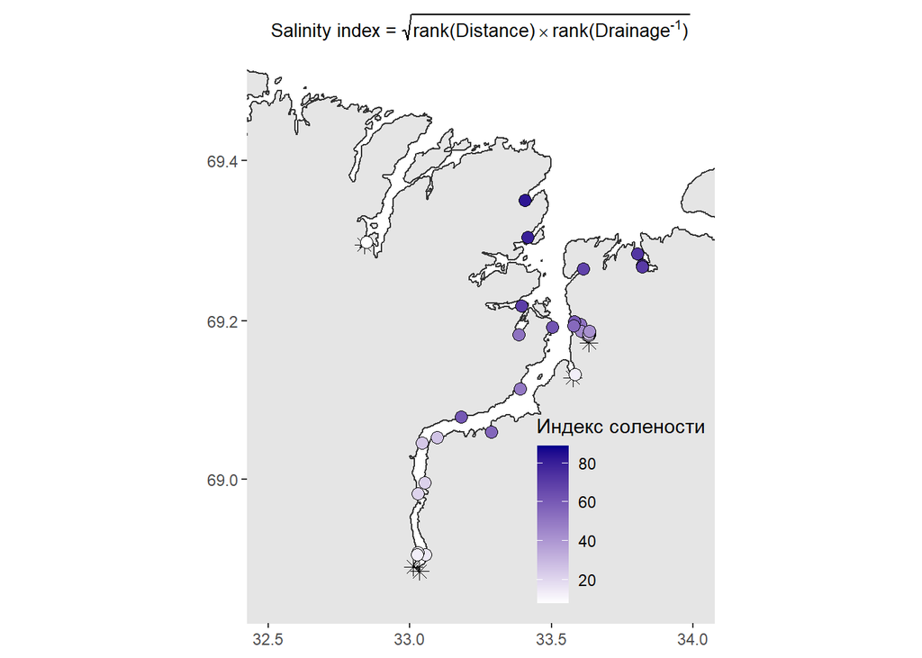

Рис. ++. Значения индекса солености в разных точках. Звездочки маркируют устья рек.

$$GAM1: \ Phybr_i = s(Ptros) + b_0 + b_1Sindex + \varepsilon_i$$

В обеих моделях непараметрическая сглаживающая функция $s(Ptros)$ описывает нелинейную связь зависимой переменной с таксономической структурой смешанного поселения. Характер этой связи демонстрирует рисунок ++.

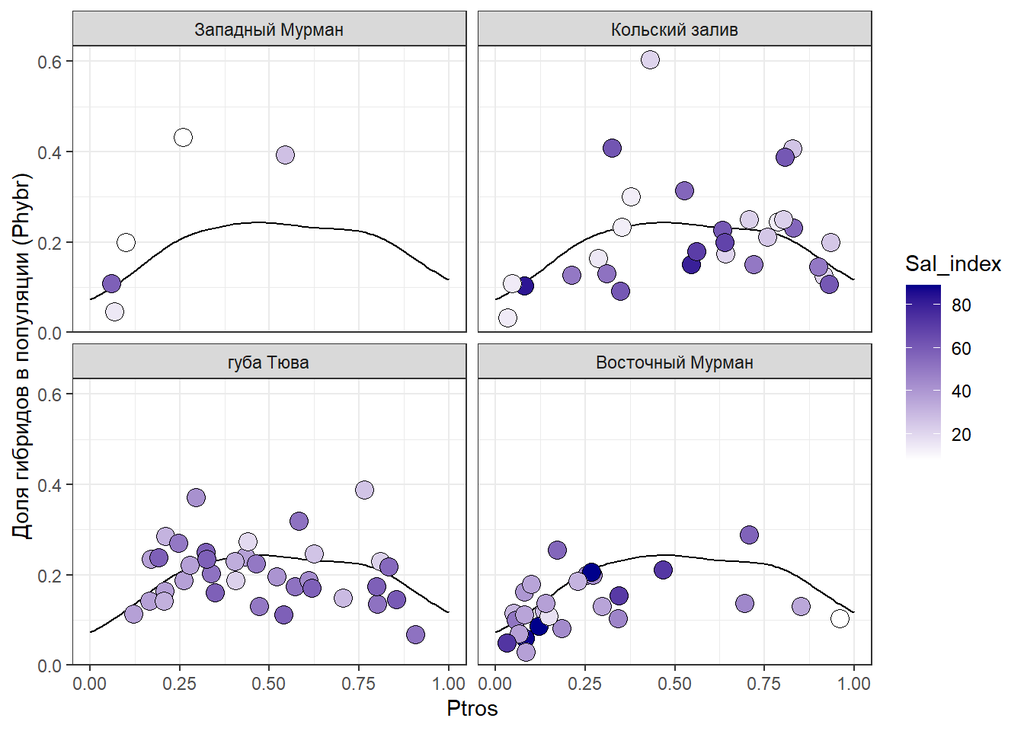

Рисунок +. Связь доли гибридов с таксономической структурой поселения, согласно модели GAM1. Каждая из четырех фасеток рисунка включает данные из одного региона. Сглаживающая функция на всех фасетках одна и та же. Для построения графиков значеине индекса солености было взято, как среднее.

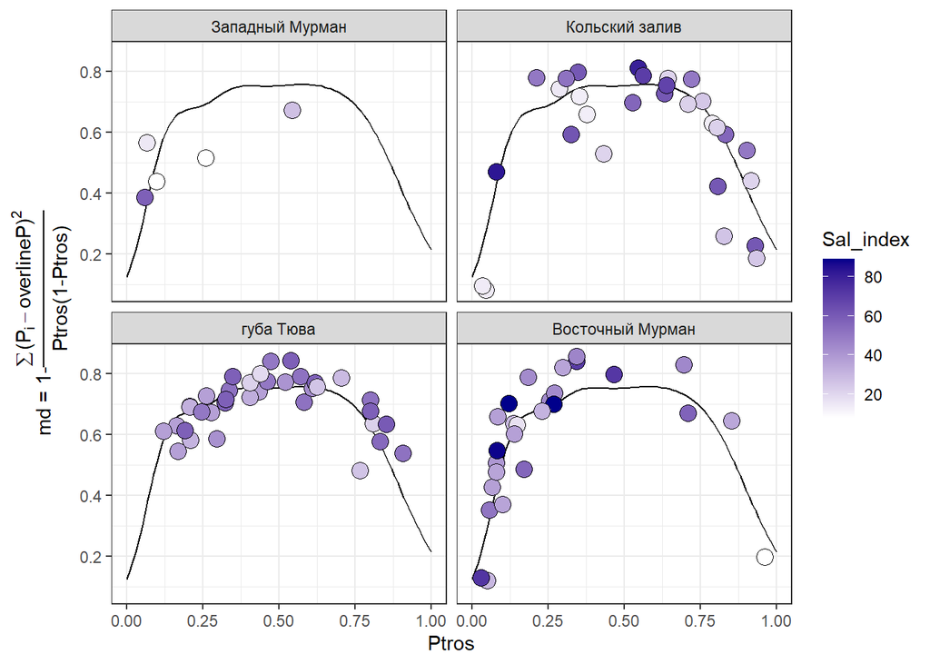

Рисунок +. Связь индекса гибридизации (md) с таксономической структурой поселения, согласно модели GAM2. Обозачения как на предыдущем рисунке.

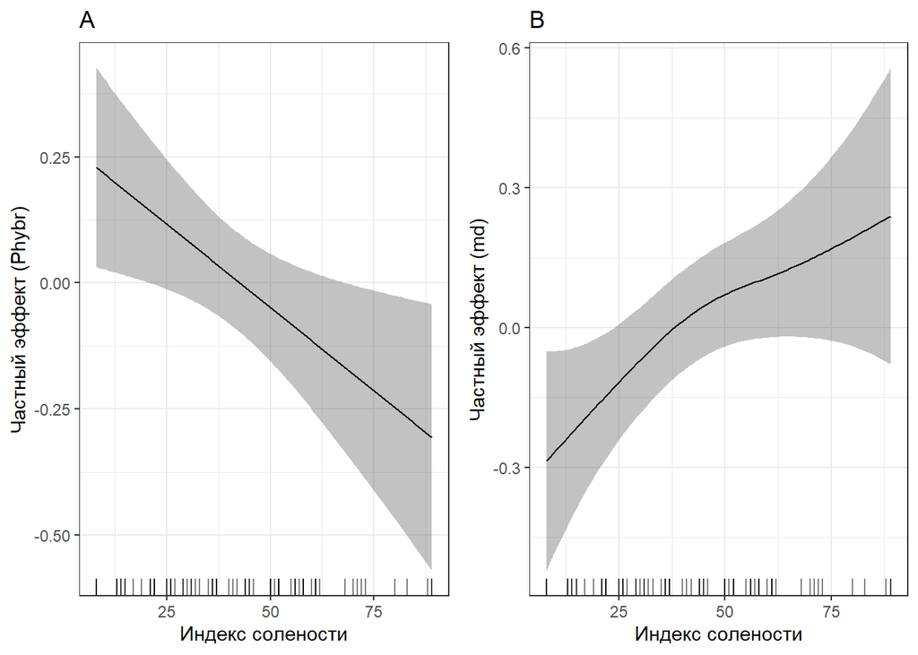

Рисунок +. Связь доли гибридов (A) и показателя генетической смешанности (B) с индексом солености, согласно модели GAM1 и GAM2, соответственно. Приведеные линии регрессии отражают частные эффекты предиктора (влияние индекса соолености при учете влияния сглаживающей функции).

Обе модели выявляют статистически значимую связь зависимых переменных с индексом солености (Таблица ++ и ++). При этом, согласно обеим моделям, по мере увеличения индекса солености степень гибридизации падает будь она оценена в терминах доли гибридов (отрицательный коэффициент при Phybr, рис. ++, A) или в терминах индекса смешанности (положительный коэффициент при md, рис. ++, B). То есть в участках, подвергающихся хроническому опреснению, степень гибридизации между *M.edulis* и *M.trossulus*, выше, чем на участках, удаленных от мощных источников опреснения.

Таблица ++. Результаты регрессионного анализа $Phybr$ в зависимости от от Ptros и индекса солености (модель GAM1).

| term | edf | ref.df | statistic | p.value |
| --- | --- | --- | --- | --- |
| s(Ptros) | 4.103205 | 5.058939 | 43.371784 | 0.0000000 |
| s(Sal_index) | 1.000196 | 1.000389 | 6.289896 | 0.0121485 |

Таблица ++. Результаты регрессионного анализа $md$ в зависимости от Ptros и индекса солености (модель GAM2).

| term | edf | ref.df | statistic | p.value |
| --- | --- | --- | --- | --- |
| s(Ptros) | 6.777581 | 7.862883 | 210.622385 | 0.0000000 |
| s(Sal_index) | 1.706005 | 2.125504 | 8.398921 | 0.0191045 |